# Functionazling Rasters From NEON

Jeff Atkins

June 21, 2016

Start by putting up objectives/tasks that students will be working though:

1. Import a raster — A lidar canopy height model (lidar/Teak_lidarCHM.tif)
2. For the CHM, set values == 0 to NA (not trees)
3. classify the raster according to some distribution – low medium and tall trees. This could be done using a histogram potentially or we could just decide that <2m is generally grasses / understory, <6m small trees,and the rest are tall trees. A function could import the desired thresholds. Visualize histogram/density and plot vertical cutoff lines.
4. PLOT - layer the classified raster on top of the hillshade, add a legend for each “class” - legends are super tricky to simplifying this process with a function would be good. see: http://neon-workwithdata.github.io/neon-data-institute-2016/R/classify-by-threshold-R/ for my take on forcing a legend outside of the plot area using par settings. You may have other better forms of magic to make this work well. :)
5. Export the plot figure to a pdf – publishable
6. Export the classified raster as a geotiff with NaFlagg = -9999 to an outputs folder.

```r
library(raster)
library(rgdal)
library(magrittr)
source("scripts/functions.R")
```

## Step One: Import Raster

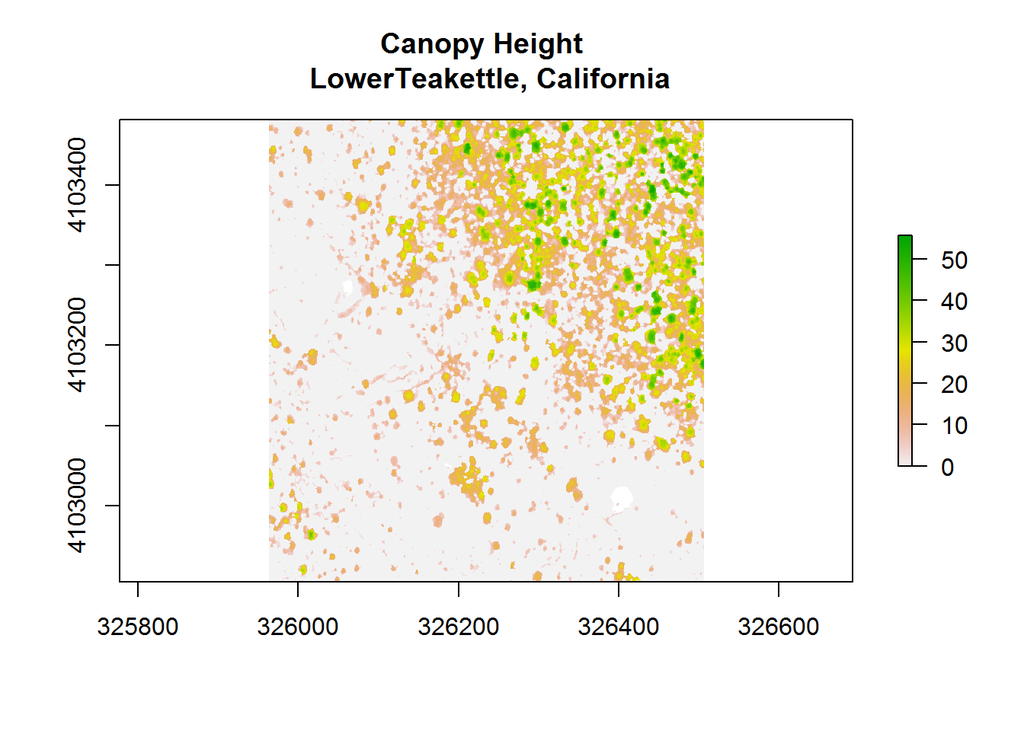

```r
#### PARAMETERS
chm_file <-("../NEONdata/D17-California/TEAK/2013/lidar/Teak_lidarCHM.tif")

# Threshold breaks for canopy height in (m)
chosen.breaks <- c(6, 30, 50, 100)



chm <- raster(chm_file)

#quick sanity check
plot(chm,
     main="Canopy Height \n LowerTeakettle, California")
```

## Step Two: Set values == 0 to NA (not trees)

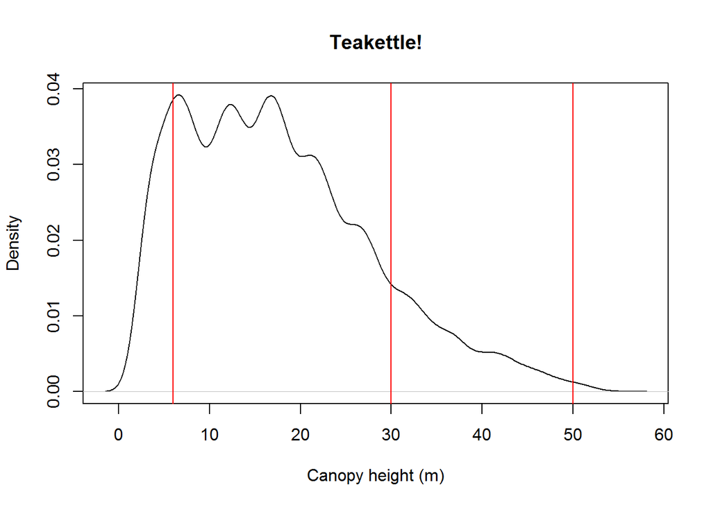

```r
#Sets those 0s to NA
chm[ chm <= 0 ] <- NA



density_plot_from_chm(chm, "Teakettle!", chosen.breaks)
```

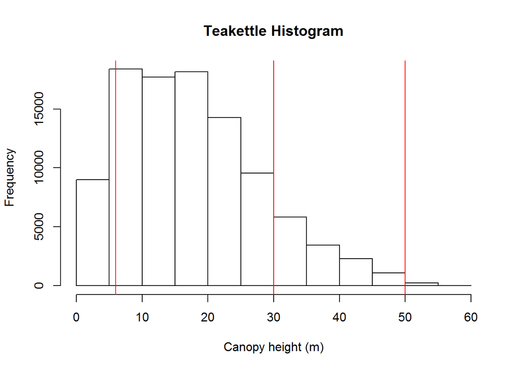

```r
hist_plot_from_chm(chm, "Teakettle Histogram", chosen.breaks)
```

```r
make_pdf(density_plot_from_chm(chm,
                               title = "Canopy heights for NEON Teakettle",
          chosen.breaks),
         filename = "outputs/teak_chm_density.pdf", width = 8, height = 6)
```

```
## Creating: outputs/teak_chm_density.pdf
```

```r
make_pdf(hist_plot_from_chm(chm,
                               title = "Canopy heights for NEON TeaKettle",
                               chosen.breaks),
         filename = "outputs/teak_chm_hist.pdf", width = 8, height = 6)
```

```
## Creating: outputs/teak_chm_hist.pdf
```

```r
reclassify.mat <- create_height_class_matrix(chosen.breaks)
reclassified.chm <- reclassify(chm, reclassify.mat)

#plotting reclassified chm
make_pdf(plot_reclassified_raster(reclassified.chm,
                                  "Teakettle",
                                  chosen.breaks),
         filename = "outputs/teakettle_reclassified.pdf")
```

```
## Creating: outputs/teakettle_reclassified.pdf
```

```r
# writeRaster(chm.class,
#             filename="outputs/Teak_nsAspect.tif",
#             format="GTiff",
#             options="COMPRESS=LZW",
#             overwrite = TRUE,
#             NAflag = -9999)
#
#
####This creates a great log session text file at the end!!!!!!
sink(paste0(format(Sys.time(), "sessioninfo/%Y-%m-%d_%H%M%S"),
"_sessionInfo.txt"))     #zero after paste has no spaces
```

```r
sink()
```